# Exercício 1 resolvido

Mauricio Camargo

13 de setembro de 2017

# Resolução do Exercício 1

## Preparando os dados

### Abrindo a planilha do Excel chamada exerc1.xlsx

```r
library(readxl)
dd=read_excel("~/Dropbox/000Comunidades-Oceano2017/Aula3/exerc1.xlsx")

library(knitr)
kable(dd)
```

| Amostra | Local | Sp1 | Sp2 | Sp3 | Sp4 | Sp5 | Sp6 | Sp7 | Sp8 | Sp9 | Sp10 |
| --- | --- | --- | --- | --- | --- | --- | --- | --- | --- | --- | --- |
| A1 | Norte | 5 | 0 | 0 | 65 | 5 | 0 | 0 | 0 | 0 | 0 |
| A2 | Norte | 0 | 0 | 0 | 25 | 39 | 0 | 6 | 23 | 0 | 0 |
| A3 | Norte | 0 | 0 | 0 | 6 | 42 | 0 | 6 | 31 | 0 | 0 |
| A4 | Norte | 0 | 0 | 0 | 0 | 0 | 0 | 0 | 40 | 0 | 14 |
| A5 | Norte | 1 | 1 | 1 | 1 | 1 | 1 | 1 | 1 | 1 | 51 |
| A6 | Sul | 6 | 6 | 6 | 6 | 6 | 6 | 6 | 6 | 6 | 6 |
| A7 | Sul | 0 | 0 | 21 | 0 | 0 | 5 | 0 | 0 | 20 | 0 |
| A8 | Sul | 0 | 0 | 0 | 0 | 13 | 0 | 6 | 37 | 0 | 0 |
| A9 | Sul | 0 | 0 | 0 | 60 | 47 | 0 | 4 | 0 | 0 | 0 |
| A10 | Sul | 0 | 0 | 0 | 72 | 34 | 0 | 0 | 0 | 0 | 0 |

### Separando o dataframe dd em dois: fatores e numéricos

```r
ddf=dd[,1:2] #Cria o dataframe ddf, que armazenará as duas primeiras colunas do dataframe dd
kable(ddf) #A função kable serve para formatar a tabela para impressão
```

| Amostra | Local |
| --- | --- |
| A1 | Norte |
| A2 | Norte |
| A3 | Norte |
| A4 | Norte |
| A5 | Norte |
| A6 | Sul |
| A7 | Sul |
| A8 | Sul |
| A9 | Sul |
| A10 | Sul |

```r
ddn=dd[,3:12] #Cria o dataframe ddn, que armazenará as colunas de 3 até 12.
kable(ddn)
```

| Sp1 | Sp2 | Sp3 | Sp4 | Sp5 | Sp6 | Sp7 | Sp8 | Sp9 | Sp10 |
| --- | --- | --- | --- | --- | --- | --- | --- | --- | --- |
| 5 | 0 | 0 | 65 | 5 | 0 | 0 | 0 | 0 | 0 |
| 0 | 0 | 0 | 25 | 39 | 0 | 6 | 23 | 0 | 0 |
| 0 | 0 | 0 | 6 | 42 | 0 | 6 | 31 | 0 | 0 |
| 0 | 0 | 0 | 0 | 0 | 0 | 0 | 40 | 0 | 14 |
| 1 | 1 | 1 | 1 | 1 | 1 | 1 | 1 | 1 | 51 |
| 6 | 6 | 6 | 6 | 6 | 6 | 6 | 6 | 6 | 6 |
| 0 | 0 | 21 | 0 | 0 | 5 | 0 | 0 | 20 | 0 |
| 0 | 0 | 0 | 0 | 13 | 0 | 6 | 37 | 0 | 0 |
| 0 | 0 | 0 | 60 | 47 | 0 | 4 | 0 | 0 | 0 |
| 0 | 0 | 0 | 72 | 34 | 0 | 0 | 0 | 0 | 0 |

## Questões

**1.** Calcule os principais descritores univariados: o número de indivíduos (N) e o número de espécies (S)

```r
library(vegan)
S=specnumber(ddn)
N=rowSums(ddn)
kable(cbind(ddf,S,N))
```

| Amostra | Local | S | N |
| --- | --- | --- | --- |
| A1 | Norte | 3 | 75 |
| A2 | Norte | 4 | 93 |
| A3 | Norte | 4 | 85 |
| A4 | Norte | 2 | 54 |
| A5 | Norte | 10 | 60 |
| A6 | Sul | 10 | 60 |
| A7 | Sul | 3 | 46 |
| A8 | Sul | 3 | 56 |
| A9 | Sul | 3 | 111 |
| A10 | Sul | 2 | 106 |

**2.** A seguir calcule o índice de riqueza de espécies de Margalef, usando N e S

```r
Dmg=(S-1)/log(N) #Riqueza de Margalef
kable(cbind(ddf,S,N,Dmg))
```

| Amostra | Local | S | N | Dmg |
| --- | --- | --- | --- | --- |
| A1 | Norte | 3 | 75 | 0.4632323 |
| A2 | Norte | 4 | 93 | 0.6618718 |
| A3 | Norte | 4 | 85 | 0.6752725 |
| A4 | Norte | 2 | 54 | 0.2506904 |
| A5 | Norte | 10 | 60 | 2.1981540 |
| A6 | Sul | 10 | 60 | 2.1981540 |
| A7 | Sul | 3 | 46 | 0.5223785 |
| A8 | Sul | 3 | 56 | 0.4968510 |
| A9 | Sul | 3 | 111 | 0.4246708 |
| A10 | Sul | 2 | 106 | 0.2144340 |

**3.** Depois, os índices de diversidade de espécies de Simpson (1 – D) e Shannon-Wienner (H), usando a abundância relativa das espécies

```r
D=diversity(ddn, "simpson")
D=1-D   #Simpson é expresso como 1-D
H=diversity(ddn, "shannon")
```

**Esta é a tabela final dos Descritores Univariados**

```r
tab=cbind(ddf,S,N,Dmg,D,H)
kable(tab)
```

| Amostra | Local | S | N | Dmg | D | H |
| --- | --- | --- | --- | --- | --- | --- |
| A1 | Norte | 3 | 75 | 0.4632323 | 0.7600000 | 0.4850941 |
| A2 | Norte | 4 | 93 | 0.6618718 | 0.3134466 | 1.2399358 |
| A3 | Norte | 4 | 85 | 0.6752725 | 0.3871280 | 1.0904531 |
| A4 | Norte | 2 | 54 | 0.2506904 | 0.6159122 | 0.5722807 |
| A5 | Norte | 10 | 60 | 2.1981540 | 0.7250000 | 0.7522928 |
| A6 | Sul | 10 | 60 | 2.1981540 | 0.1000000 | 2.3025851 |
| A7 | Sul | 3 | 46 | 0.5223785 | 0.4092628 | 0.9613195 |
| A8 | Sul | 3 | 56 | 0.4968510 | 0.5019133 | 0.8521577 |
| A9 | Sul | 3 | 111 | 0.4246708 | 0.4727701 | 0.8161717 |
| A10 | Sul | 2 | 106 | 0.2144340 | 0.5642577 | 0.6274370 |

**4.** Discuta sobre riqueza e diversidade das amostras A5 e A6

**Resposta:**  
Na amostra A5, todas as espécies possuíam apenas 1 indivíduo, exceto a última (sp10), que continha 51 indivíduos.

Na amostra A6, todas as espécies continham 6 indivíduos.

Nota-se que a riqueza medida por S, N e Dmg são idênticas entre as amostras A5 e A6, mesmo com as discrepâncias na distribuição das espécies entre as duas amostras.

A diversidade de Simpson (D) é sensível a estas diferenças. Quando existe homogeneidade total entre as espécies, como em A6, D é igual a 0,1. Quando a abundância é diferente em apenas uma espécie, como em A5, D é igual a 0,725.

A diversidade de Shannon (H) é muito mais sensível a estas variações. Em situação de homogeneidade, como em A6, H é igual 2,30. Quando a abundância difere em apenas uma espécies, como em A5, H é igual a 0,75.

**5.** Calcule a média e o desvio padrão entre os locais Norte e Sul, número de indivíduos (N) e número de espécies (S)

```r
library(doBy)
kable(summaryBy(S+N~Local,FUN=c(mean,sd),data=tab))
```

| Local | S.mean | N.mean | S.sd | N.sd |
| --- | --- | --- | --- | --- |
| Norte | 4.6 | 73.4 | 3.130495 | 16.41036 |
| Sul | 4.2 | 75.8 | 3.271085 | 30.33480 |

**6.** Faça um gráfico de barras com barras de erro representadas pelo erro padrão, usando o pacote sciplot, comparando as amostras de Norte e Sul para todos os descritores univariados

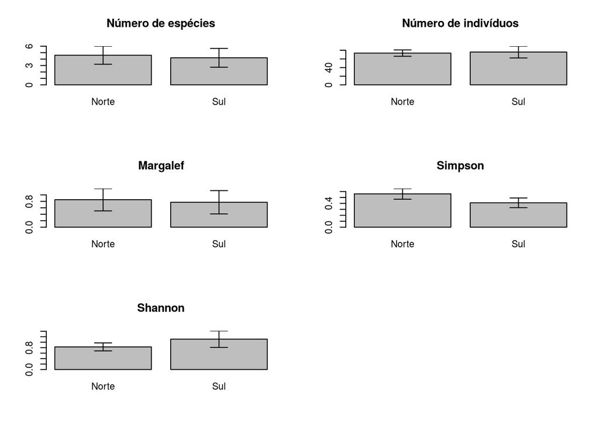

```r
library(sciplot)
par(mfrow=c(3,2)) #Cria uma grade para 6 gráficos
bargraph.CI(tab$Local,tab$S,main='Número de espécies')
bargraph.CI(tab$Local,tab$N,main='Número de indivíduos')
bargraph.CI(tab$Local,tab$Dmg,main='Margalef')
bargraph.CI(tab$Local,tab$D,main='Simpson')
bargraph.CI(tab$Local,tab$H,main='Shannon')
```

**7.** Faça um teste-t para cada um dos descritores univariados entre os locais norte e sul

7.1. Número de espécies

Aceita H0

```r
t.test(tab$S ~ tab$Local)
```

```
##
##  Welch Two Sample t-test
##
## data:  tab$S by tab$Local
## t = 0.19755, df = 7.9846, p-value = 0.8483
## alternative hypothesis: true difference in means is not equal to 0
## 95 percent confidence interval:
##  -4.270869  5.070869
## sample estimates:
## mean in group Norte   mean in group Sul
##                 4.6                 4.2
```

7.2. Número de indivíduos

Aceita H0

```r
t.test(tab$N ~ tab$Local)
```

```
##
##  Welch Two Sample t-test
##
## data:  tab$N by tab$Local
## t = -0.1556, df = 6.1565, p-value = 0.8813
## alternative hypothesis: true difference in means is not equal to 0
## 95 percent confidence interval:
##  -39.9098  35.1098
## sample estimates:
## mean in group Norte   mean in group Sul
##                73.4                75.8
```

7.3. Margalef

Aceita H0

```r
t.test(tab$Dmg ~ tab$Local)
```

```
##
##  Welch Two Sample t-test
##
## data:  tab$Dmg by tab$Local
## t = 0.15716, df = 7.9857, p-value = 0.879
## alternative hypothesis: true difference in means is not equal to 0
## 95 percent confidence interval:
##  -1.074313  1.231406
## sample estimates:
## mean in group Norte   mean in group Sul
##           0.8498442           0.7712977
```

7.4. Simpson

Aceita H0

```r
t.test(tab$D ~ tab$Local)
```

```
##
##  Welch Two Sample t-test
##
## data:  tab$D by tab$Local
## t = 1.2441, df = 7.9239, p-value = 0.249
## alternative hypothesis: true difference in means is not equal to 0
## 95 percent confidence interval:
##  -0.1290695  0.4303827
## sample estimates:
## mean in group Norte   mean in group Sul
##           0.5602974           0.4096408
```

7.5. Shannon

Aceita H0

```r
t.test(tab$H ~ tab$Local)
```

```
##
##  Welch Two Sample t-test
##
## data:  tab$H by tab$Local
## t = -0.84512, df = 5.7713, p-value = 0.4317
## alternative hypothesis: true difference in means is not equal to 0
## 95 percent confidence interval:
##  -1.113936  0.546090
## sample estimates:
## mean in group Norte   mean in group Sul
##           0.8280113           1.1119342
```